# HCC case study — frozen posteriorHCA baseline transfer to GeoMx

Source-feature-excluded liver-NK reference retrieval on an unseen spatial platform

Author

Affiliation

Chen Zhan

SAiGENCI, The University of Adelaide

Published

12 Aug 2026

Abstract

This report tests one question: can a frozen posteriorHCA healthy-liver NK baseline be transported to GeoMx, a spatial assay that was not represented when posteriorHCA was fitted? The external observations are within-patient tumour-centre contrasts between protein-defined NK-selected and cold-tumour regions from six HCC patients. The validation excludes genes selected by the source study, the TIMES biomarkers and the transcripts used to define the regions. A successful result requires the posteriorHCA liver-NK reference to match the GeoMx contrast better than six alternative cell references and to score highly under exhaustive reallocations of the spatial labels. A dataset-balanced, unmatched empirical HCA centroid is included only as a descriptive sensitivity analysis. The estimand is relative cross-gene structure; this report does not calibrate posteriorHCA counts to GeoMx Q3-normalized expression.

# Analysis question and claim boundary

The analysis asks whether a healthy cell-state reference learned from atlas pseudobulk data retains its biological structure on an unseen spatial platform:

> Do genes predicted by frozen posteriorHCA models to be relatively enriched in healthy liver NK cells also increase in independently labelled NK-selected GeoMx tumour-centre regions, and is liver NK the best-matching reference among seven candidate cell types?

The outcome is **reference retrieval**, not equality of measurement scales. Both sides of the comparison are contrasts:

$$D_{gp} =
\operatorname{median}_{r \in \mathrm{NK\ selected\ TC}}
\{\log_2 Q3_{gpr}\}
-
\operatorname{median}_{r \in \mathrm{cold\ TC}}
\{\log_2 Q3_{gpr}\},$$

and

$$H_{gc} = \log\mu_{gc}
- \frac{1}{7}\sum_{c'=1}^{7}\log\mu_{gc'}.$$

Here, $D_{gp}$ is the GeoMx contrast for gene $g$ and patient $p$; $H_{gc}$ is the posteriorHCA specificity of candidate cell type $c$ from its comprehensive healthy-liver grand-mean $\log\mu$. No GeoMx assay coefficient is added to or estimated inside posteriorHCA.

The analysis can support transport of **relative cell-reference structure**. It cannot establish absolute GeoMx calibration, predictive-interval coverage, pure-cell expression or recurrence prediction.

Because the model stores are frozen, convergence diagnostics are audited but not repaired here. The operational retrieval excludes catastrophic `FAIL` fits and visibly retains intermediate `WARN` fits. It can be promoted from an exploratory deployment result to strong inferential evidence only if a useful gene universe also passes the strict diagnostic criteria in all seven models.

# Setup

```r
suppressPackageStartupMessages({
  library(tibble)
  library(tidyr)
  library(dplyr)
  library(readr)
  library(purrr)
  library(stringr)
  library(forcats)
  library(ggplot2)
  library(scales)
  library(targets)
  library(brms)
  library(posterior)
  library(AnnotationDbi)
  library(org.Hs.eg.db)
})

theme_set(theme_minimal(base_size = 11))
set.seed(params$seed)

candidate_cells <- unlist(params$candidate_cell_types)
target_cell <- params$target_cell_type
output_dir <- params$output_dir
dir.create(output_dir, recursive = TRUE, showWarnings = FALSE)

core_rdata <- file.path(
  params$case_dir,
  "codeocean/data/Input_1_Spatial_transcriptomics_analysis",
  "transcriptome_differential_analysis_input_1.RData"
)

source_de_rdata <- file.path(
  params$case_dir,
  "codeocean/data/Input_1_Spatial_transcriptomics_analysis",
  "differential_gene_expression.RData"
)

cell_labels <- c(
  nk = "NK",
  `cd8.tem` = "CD8 TEM",
  mait = "MAIT",
  tgd = "gamma-delta T",
  monocytic = "Monocytic",
  macrophage = "Macrophage",
  epithelial = "Epithelial"
)

method_colours <- c(
  posteriorHCA = "#2878B5",
  `Naive empirical HCA` = "#E08A2E"
)
```

# Helper functions

All data preparation, reference construction and validation helpers used by the report are defined below. The report does not source external analysis scripts.

## Data and contrast helpers

```r
load_rdata_environment <- function(path) {
  environment <- new.env(parent = emptyenv())
  load(path, envir = environment)
  environment
}

row_median <- function(x) {
  apply(x, 1, stats::median)
}

make_patient_contrast <- function(
    patient,
    genes,
    metadata,
    log_expression
) {
  patient_regions <- metadata |>
    filter(.data$patient_id == patient)

  nk_regions <- patient_regions$roi_key[
    patient_regions$region_group == "NK-selected TC"
  ]
  cold_regions <- patient_regions$roi_key[
    patient_regions$region_group == "Cold TC"
  ]

  tibble(
    gene = genes,
    patient_id = patient,
    panel = dplyr::first(patient_regions$panel),
    delta_q3 =
      row_median(log_expression[genes, nk_regions, drop = FALSE]) -
      row_median(log_expression[genes, cold_regions, drop = FALSE])
  )
}
```

## posteriorHCA reference helpers

These helpers follow the same comprehensive healthy-liver baseline used in the universal baseline report: equal-weight grand mean of $\log\mu$ over the factor grid, with a new `dataset_id` level drawn from the hierarchical prior.

```r
model_store <- function(cell_type) {
  file.path(
    params$model_store_root,
    paste0("V1_", cell_type),
    "_targets"
  )
}

read_model_inventory <- function(cell_type) {
  store <- model_store(cell_type)

  targets::tar_meta(
    starts_with("estimates_chunk_"),
    store = store
  ) |>
    filter(.data$type == "branch") |>
    transmute(
      cell_type = cell_type,
      .feature = str_extract(
        .data$warnings,
        "(?<=Gene:___)ENSG\\d+(?=___)"
      ),
      target_name = .data$name,
      store = store
    ) |>
    filter(!is.na(.data$.feature))
}

read_model_fit <- function(target_name, store) {
  targets::tar_read_raw(target_name, store = store)$brms_fit[[1]]
}

fit_levels <- function(fit, var) {
  if (!var %in% names(fit$data)) {
    return(character(0))
  }

  values <- fit$data[[var]]
  lv <- if (is.factor(values)) {
    base::levels(values)
  } else {
    sort(unique(as.character(values)))
  }

  lv[!is.na(lv) & nzchar(lv)]
}

build_comprehensive_grid <- function(
    fit,
    tissue_group = params$baseline_tissue_group,
    marginalize_over = c(
      "sex",
      "age_decade",
      "ethnicity_groups",
      "assay_groups_altered"
    ),
    new_level_cols = "dataset_id_altered",
    new_level_tag = "__comprehensive_healthy_baseline__"
) {
  level_list <- lapply(
    intersect(marginalize_over, names(fit$data)),
    function(col) fit_levels(fit, col)
  )
  names(level_list) <- intersect(marginalize_over, names(fit$data))
  level_list <- level_list[lengths(level_list) > 0]

  grid <- if (length(level_list)) {
    tidyr::expand_grid(!!!level_list)
  } else {
    tibble(.rows = 1)
  }

  grid$disease_groups_altered <- "Normal"
  grid$tissue_groups <- tissue_group
  grid$offset <- 0

  for (col in new_level_cols) {
    grid[[col]] <- new_level_tag
  }

  grid
}

fit_diagnostics <- function(fit) {
  draw_diagnostics <- posterior::summarise_draws(
    posterior::as_draws_array(fit),
    "rhat",
    "ess_bulk"
  )

  divergent_draws <- brms::nuts_params(fit) |>
    filter(.data$Parameter == "divergent__")

  tibble(
    maximum_rhat = max(draw_diagnostics$rhat, na.rm = TRUE),
    minimum_ess_bulk = min(draw_diagnostics$ess_bulk, na.rm = TRUE),
    post_warmup_transitions = nrow(divergent_draws),
    divergent_transitions = sum(divergent_draws$Value == 1),
    divergent_percent = mean(divergent_draws$Value == 1) * 100
  )
}

posterior_liver_draws <- function(fit, n_draws, seed) {
  nd_grid <- build_comprehensive_grid(fit)
  n_use <- min(n_draws, posterior::ndraws(posterior::as_draws_df(fit)))

  set.seed(seed)
  log_mu <- brms::posterior_linpred(
    fit,
    newdata = nd_grid,
    transform = FALSE,
    re_formula = NULL,
    allow_new_levels = TRUE,
    sample_new_levels = "gaussian",
    ndraws = n_use
  )

  tibble(
    draw = seq_len(nrow(log_mu)),
    reference_log_mu = rowMeans(log_mu),
    n_grid_rows = nrow(nd_grid)
  )
}

empirical_liver_centroid <- function(fit) {
  healthy_liver <- fit$data |>
    filter(
      .data$disease_groups_altered == "Normal",
      .data$tissue_groups == params$baseline_tissue_group
    ) |>
    mutate(
      normalized_log_expression = log1p(.data$counts / exp(.data$offset))
    )

  dataset_means <- healthy_liver |>
    group_by(.data$dataset_id_altered) |>
    summarise(
      dataset_mean = mean(.data$normalized_log_expression),
      n_samples = n(),
      .groups = "drop"
    )

  tibble(
    empirical_log_expression = mean(dataset_means$dataset_mean),
    n_empirical_datasets = nrow(dataset_means),
    n_empirical_samples = sum(dataset_means$n_samples)
  )
}

compute_reference_job <- function(job, cache_dir) {
  cache_path <- file.path(
    cache_dir,
    paste0(job$job_id, "_", job$cell_type, "_", job$.feature, ".rds")
  )

  if (!isTRUE(params$refresh_references) && file.exists(cache_path)) {
    return(readRDS(cache_path))
  }

  fit <- read_model_fit(job$target_name, job$store)

  result <- list(
    posterior_draws = posterior_liver_draws(
      fit = fit,
      n_draws = params$n_posterior_draws,
      seed = params$seed + job$job_id
    ) |>
      mutate(
        gene = job$gene,
        .feature = job$.feature,
        cell_type = job$cell_type,
        .before = 1
      ),
    diagnostics = bind_cols(
      tibble(
        gene = job$gene,
        .feature = job$.feature,
        cell_type = job$cell_type
      ),
      fit_diagnostics(fit),
      empirical_liver_centroid(fit)
    )
  )

  saveRDS(result, cache_path, compress = "gzip")
  result
}
```

## Retrieval and label-null helpers

```r
calculate_reference_correlations <- function(
    patient_contrasts,
    reference_values,
    method
) {
  patient_contrasts |>
    inner_join(
      reference_values,
      by = c("gene", ".feature")
    ) |>
    group_by(
      .data$patient_id,
      .data$panel,
      .data$cell_type
    ) |>
    summarise(
      correlation = cor(
        .data$delta_q3,
        .data$reference_value,
        method = "spearman"
      ),
      n_genes = n(),
      .groups = "drop"
    ) |>
    mutate(method = method, .before = 1)
}

summarise_retrieval <- function(correlations, target_cell = "nk") {
  correlations |>
    group_by(
      .data$method,
      .data$patient_id,
      .data$panel
    ) |>
    group_modify(function(data, key) {
      target_correlation <- data$correlation[
        data$cell_type == target_cell
      ][[1]]

      best_other <- data |>
        filter(.data$cell_type != target_cell) |>
        dplyr::slice_max(
          order_by = .data$correlation,
          n = 1,
          with_ties = FALSE
        )

      tibble(
        n_genes = dplyr::first(data$n_genes),
        nk_correlation = target_correlation,
        best_other_cell = best_other$cell_type,
        best_other_correlation = best_other$correlation,
        nk_margin = target_correlation - best_other$correlation,
        nk_rank = rank(
          -data$correlation,
          ties.method = "min"
        )[data$cell_type == target_cell][[1]]
      )
    }) |>
    ungroup()
}

reference_matrix_from_long <- function(reference_values) {
  wide <- reference_values |>
    dplyr::select(gene, cell_type, reference_value) |>
    pivot_wider(
      names_from = .data$cell_type,
      values_from = .data$reference_value
    ) |>
    arrange(.data$gene)

  matrix <- as.matrix(wide[, candidate_cells, drop = FALSE])
  rownames(matrix) <- wide$gene
  matrix
}

retrieval_margin <- function(
    delta,
    reference_matrix,
    target_cell = "nk"
) {
  genes <- intersect(names(delta), rownames(reference_matrix))

  correlations <- apply(
    reference_matrix[genes, , drop = FALSE],
    2,
    function(reference) {
      cor(delta[genes], reference, method = "spearman")
    }
  )

  other_correlations <- correlations[
    names(correlations) != target_cell
  ]
  best_other <- names(which.max(other_correlations))

  tibble(
    nk_correlation = unname(correlations[target_cell]),
    best_other_cell = best_other,
    best_other_correlation = unname(other_correlations[best_other]),
    nk_margin = unname(
      correlations[target_cell] - other_correlations[best_other]
    )
  )
}

exact_patient_permutations <- function(
    patient,
    genes,
    metadata,
    log_expression,
    reference_matrix,
    method
) {
  patient_regions <- metadata |>
    filter(.data$patient_id == patient)

  all_regions <- patient_regions$roi_key
  observed_nk <- patient_regions$roi_key[
    patient_regions$region_group == "NK-selected TC"
  ]
  assignments <- combn(
    all_regions,
    length(observed_nk),
    simplify = FALSE
  )

  map_dfr(seq_along(assignments), function(permutation_id) {
    nk_regions <- assignments[[permutation_id]]
    cold_regions <- setdiff(all_regions, nk_regions)

    delta <-
      row_median(log_expression[genes, nk_regions, drop = FALSE]) -
      row_median(log_expression[genes, cold_regions, drop = FALSE])
    names(delta) <- genes

    retrieval_margin(delta, reference_matrix) |>
      mutate(
        method = method,
        patient_id = patient,
        panel = dplyr::first(patient_regions$panel),
        permutation_id = permutation_id,
        observed_labels = setequal(nk_regions, observed_nk),
        .before = 1
      )
  })
}

summarise_exact_test <- function(permutation_results) {
  permutation_results |>
    group_by(
      .data$method,
      .data$patient_id,
      .data$panel
    ) |>
    summarise(
      n_assignments = n(),
      observed_margin = .data$nk_margin[.data$observed_labels][[1]],
      observed_percentile = mean(
        .data$nk_margin <= observed_margin
      ),
      upper_tail_fraction = mean(
        .data$nk_margin >= observed_margin
      ),
      .groups = "drop"
    )
}

simulate_joint_null <- function(
    permutation_results,
    n_draws,
    seed
) {
  methods <- unique(permutation_results$method)

  map_dfr(seq_along(methods), function(method_id) {
    method <- methods[[method_id]]
    method_results <- permutation_results |>
      filter(.data$method == method)
    patient_margins <- split(
      method_results$nk_margin,
      method_results$patient_id
    )

    set.seed(seed + method_id)
    sampled_margins <- vapply(
      patient_margins,
      sample,
      numeric(n_draws),
      size = n_draws,
      replace = TRUE
    )

    tibble(
      method = method,
      joint_draw = seq_len(n_draws),
      cohort_mean_margin = rowMeans(sampled_margins)
    )
  })
}

summarise_joint_null <- function(permutation_results, joint_null) {
  observed <- permutation_results |>
    filter(.data$observed_labels) |>
    group_by(.data$method) |>
    summarise(
      observed_cohort_mean_margin = mean(.data$nk_margin),
      .groups = "drop"
    )

  joint_null |>
    inner_join(observed, by = "method") |>
    group_by(.data$method, .data$observed_cohort_mean_margin) |>
    summarise(
      n_joint_draws = n(),
      observed_percentile = mean(
        .data$cohort_mean_margin <= .data$observed_cohort_mean_margin
      ),
      monte_carlo_upper_tail =
        (sum(
          .data$cohort_mean_margin >= .data$observed_cohort_mean_margin
        ) + 1) / (n() + 1),
      .groups = "drop"
    )
}
```

# Frozen design and HCC data

The external spatial data and author-defined region labels come from Jia *et al.* (2025), *Spatial immune scoring system predicts hepatocellular carcinoma recurrence*, *Nature* **640**, 1029–1040 ([doi:10.1038/s41586-025-08668-x](https://doi.org/10.1038/s41586-025-08668-x)). Only files present in the audited local Code Ocean export are used; unavailable raw GeoMx data and supplementary annotations are not reconstructed.

The primary biological unit is the patient; individual GeoMx regions are spatial sampling units. Only matched tumour-centre comparisons are used, so each patient acts as their own spatial control. Recurrence is retained only as source metadata and is not used in this report.

```r
core <- load_rdata_environment(core_rdata)
source_de <- load_rdata_environment(source_de_rdata)

geomx_expression <- as.matrix(core$data_gene_df_ed)
mode(geomx_expression) <- "numeric"

geomx_metadata <- as.data.frame(
  t(core$data_meta_df_ed),
  stringsAsFactors = FALSE
) |>
  rownames_to_column("roi_key") |>
  mutate(
    author_index = as.integer(str_remove(.data$roi_key, "^\\.\\.\\.")),
    patient_id = .data$sampleid,
    panel = if_else(
      str_detect(.data$sampleid_raw, "_2_14Dec"),
      "low coverage",
      "high coverage"
    ),
    region_group = case_when(
      .data$author_index %in% core$NKatTumor_indx ~ "NK-selected TC",
      str_detect(
        .data$label,
        regex("^cold tumor", ignore_case = TRUE)
      ) ~ "Cold TC",
      TRUE ~ NA_character_
    ),
    region_detail = case_when(
      .data$region_group == "Cold TC" ~ "cold tumour",
      str_detect(
        .data$label,
        regex("CD3 rich too", ignore_case = TRUE)
      ) ~ "CD57/CD3 overlap",
      .data$region_group == "NK-selected TC" ~ "CD57-rich",
      TRUE ~ NA_character_
    )
  )

primary_patients <- c("A24", "A29", "A10", "A9", "A3", "A39")

primary_regions <- geomx_metadata |>
  filter(
    .data$patient_id %in% primary_patients,
    !is.na(.data$region_group)
  ) |>
  mutate(
    patient_id = factor(.data$patient_id, levels = primary_patients),
    region_group = factor(
      .data$region_group,
      levels = c("Cold TC", "NK-selected TC")
    )
  ) |>
  arrange(.data$patient_id, .data$region_group, .data$author_index)

region_design <- primary_regions |>
  count(
    .data$patient_id,
    .data$panel,
    .data$region_group,
    .data$region_detail,
    name = "n_regions",
    .drop = FALSE
  ) |>
  filter(.data$n_regions > 0)

write_csv(
  primary_regions,
  file.path(output_dir, "primary_tc_regions.csv")
)

region_design
```

| patient_id | panel | region_group | region_detail | n_regions |
| --- | --- | --- | --- | --- |
| A24 | high coverage | Cold TC | cold tumour | 3 |
| A24 | high coverage | NK-selected TC | CD57-rich | 2 |
| A24 | high coverage | NK-selected TC | CD57/CD3 overlap | 1 |
| A29 | high coverage | Cold TC | cold tumour | 4 |
| A29 | high coverage | NK-selected TC | CD57-rich | 4 |
| A10 | low coverage | Cold TC | cold tumour | 3 |
| A10 | low coverage | NK-selected TC | CD57-rich | 3 |
| A9 | low coverage | Cold TC | cold tumour | 3 |
| A9 | low coverage | NK-selected TC | CD57-rich | 3 |
| A3 | low coverage | Cold TC | cold tumour | 3 |

[output cut: 3 more lines]

The six patients contribute 38 regions: 19 NK-selected TC and 19 cold TC regions. Of the NK-selected regions, 12 are labelled CD57-rich and 7 are labelled CD57/CD3 overlap. The overlap is therefore part of what “NK-selected” means in this primary source-defined experiment and is reported explicitly.

# Source-excluded common gene universe

The gene universe is frozen without using the observed retrieval result. It starts from genes measured in every one of the 93 GeoMx segments, excludes all 241 source spatial genes and the transcripts used to define the CD57/CD3 regions, and then retains only unambiguous Ensembl mappings available in all seven posteriorHCA model stores.

```r
model_inventories <- map_dfr(
  candidate_cells,
  read_model_inventory
)

common_model_features <- model_inventories |>
  group_by(.data$.feature) |>
  summarise(n_cell_types = n_distinct(.data$cell_type), .groups = "drop") |>
  filter(.data$n_cell_types == length(candidate_cells)) |>
  pull(.data$.feature)
```

```r
complete_geomx_genes <- rownames(geomx_expression)[
  rowSums(is.na(geomx_expression)) == 0
]

source_genes <- bind_rows(
  source_de$fd_df,
  source_de$fd_uf,
  source_de$fu_df,
  source_de$fu_uf
) |>
  distinct(.data$gene) |>
  pull(.data$gene)

times_genes <- c("SPON2", "ZFP36L2", "ZFP36", "VIM", "HLA-DRB1")
selection_genes <- c("B3GAT1", "CD3D", "CD3E", "CD3G")

source_excluded_symbols <- setdiff(
  complete_geomx_genes,
  c(source_genes, times_genes, selection_genes)
)

gene_mapping <- AnnotationDbi::select(
  org.Hs.eg.db,
  keys = source_excluded_symbols,
  columns = "ENSEMBL",
  keytype = "SYMBOL"
) |>
  as_tibble() |>
  filter(
    !is.na(.data$ENSEMBL),
    .data$ENSEMBL %in% common_model_features
  ) |>
  distinct(.data$SYMBOL, .data$ENSEMBL) |>
  add_count(.data$SYMBOL, name = "n_model_mappings") |>
  filter(.data$n_model_mappings == 1) |>
  transmute(
    gene = .data$SYMBOL,
    .feature = .data$ENSEMBL
  ) |>
  arrange(.data$gene)

gene_universe_audit <- tibble(
  stage = c(
    "All GeoMx matrix rows",
    "Complete in all 93 GeoMx segments",
    "After source, TIMES and region-selection exclusion",
    "Available in all seven posteriorHCA stores"
  ),
  n_genes = c(
    nrow(geomx_expression),
    length(complete_geomx_genes),
    length(source_excluded_symbols),
    nrow(gene_mapping)
  )
)

write_csv(
  gene_mapping,
  file.path(output_dir, "source_excluded_gene_universe_before_model_qc.csv")
)

gene_universe_audit
```

| stage | n_genes |
| --- | --- |
| All GeoMx matrix rows | 18677 |
| Complete in all 93 GeoMx segments | 1788 |
| After source, TIMES and region-selection exclusion | 1784 |
| Available in all seven posteriorHCA stores | 396 |

The five TIMES genes are not used. None is present in the all-segment common universe, and they were selected using the same HCC source data. Among the 241 source genes, only `BIRC5` overlaps the 1,788-gene common GeoMx universe, but the full source list is excluded before model intersection.

# HCC within-patient spatial contrasts

```r
log2_q3 <- log2(geomx_expression)

hcc_contrasts_before_model_qc <- map_dfr(
  primary_patients,
  make_patient_contrast,
  genes = gene_mapping$gene,
  metadata = primary_regions,
  log_expression = log2_q3
) |>
  left_join(gene_mapping, by = "gene")

write_csv(
  hcc_contrasts_before_model_qc,
  file.path(output_dir, "hcc_tc_contrasts_before_model_qc.csv")
)

hcc_contrasts_before_model_qc |>
  group_by(.data$patient_id, .data$panel) |>
  summarise(
    n_genes = n(),
    median_delta_q3 = median(.data$delta_q3),
    .groups = "drop"
  )
```

| patient_id | panel | n_genes | median_delta_q3 |
| --- | --- | --- | --- |
| A10 | low coverage | 396 | 0.050551750 |
| A24 | high coverage | 396 | 0.050565092 |
| A29 | high coverage | 396 | 0.017398504 |
| A3 | low coverage | 396 | -0.004044414 |
| A39 | low coverage | 396 | -0.161836832 |
| A9 | low coverage | 396 | 0.010850149 |

Positive `delta_q3` means that a gene is higher in the patient’s NK-selected TC regions than in their cold TC regions. The analysis compares the ranking of these gene-wise changes with each frozen healthy cell reference; it never compares Q3 values directly with posteriorHCA counts.

# Frozen healthy-liver references

## Comprehensive healthy-liver baseline

Each gene-by-cell reference is the same comprehensive healthy-liver estimand used in the universal baseline report. Disease is fixed to Normal, tissue to liver, and offset to zero. Sex, age decade, ethnicity and assay are expanded to the full factorial of levels present in that fitted model; every grid cell receives equal weight. The scalar baseline draw is the mean of $\log\mu$ over that grid (`mean(log mu)`, not `log(mean mu)`). Dataset identity is a new shared level sampled from the hierarchical prior (`allow_new_levels = TRUE`, `sample_new_levels = "gaussian"`, `re_formula = NULL`), so dataset uncertainty enters the baseline posterior rather than being pinned at the population mean or averaged over observed dataset IDs. Retrieval still uses Spearman correlation across genes within each cell reference, so a cell-model-specific additive intercept does not change that cell’s correlation or the NK retrieval margin.

## Model evaluation and caching

For each gene and cell type, `posterior_linpred()` returns posterior draws of the comprehensive healthy-liver grand-mean $\log\mu$. The empirical benchmark uses the same fitted model’s training rows but does no modelling: it normalizes counts by their fitted offset, averages within atlas dataset and then gives each dataset equal weight. Each gene-by-cell job is written to disk immediately so an interrupted run can resume.

```r
reference_jobs <- tidyr::crossing(
  gene_mapping,
  cell_type = candidate_cells
) |>
  left_join(
    model_inventories,
    by = c(".feature", "cell_type")
  ) |>
  mutate(job_id = row_number())

reference_job_cache_dir <- file.path(
  output_dir,
  "frozen_reference_jobs"
)
dir.create(reference_job_cache_dir, recursive = TRUE, showWarnings = FALSE)

n_jobs <- nrow(reference_jobs)
results <- vector("list", n_jobs)
progress <- txtProgressBar(min = 0, max = n_jobs, style = 3)
for (i in seq_len(n_jobs)) {
  job <- reference_jobs[i, ]
  results[[i]] <- compute_reference_job(job, reference_job_cache_dir)
  setTxtProgressBar(progress, i)
  if (i == 1L || i == n_jobs || i %% 25L == 0L) {
    message(
      sprintf(
        "\n[%d/%d] %s | %s | %s",
        i,
        n_jobs,
        job$cell_type,
        job$gene,
        job$.feature
      )
    )
  }
}
close(progress)
```

```r
reference_results <- list(
  posterior_draws = map_dfr(results, "posterior_draws"),
  diagnostics = map_dfr(results, "diagnostics")
)
```

## Model-diagnostic triage and final analysis genes

```r
reference_diagnostics <- reference_results$diagnostics |>
  mutate(
    diagnostic_status = case_when(
      .data$maximum_rhat > params$fail_maximum_rhat |
        .data$divergent_percent >= params$fail_minimum_divergence_percent ~
        "FAIL",
      .data$maximum_rhat <= params$pass_maximum_rhat &
        .data$divergent_percent < params$pass_maximum_divergence_percent ~
        "PASS",
      TRUE ~ "WARN"
    ),
    diagnostic_status = factor(
      .data$diagnostic_status,
      levels = c("PASS", "WARN", "FAIL")
    )
  )

gene_model_quality <- reference_diagnostics |>
  group_by(.data$gene, .data$.feature) |>
  summarise(
    n_models = n(),
    all_models_pass = all(.data$diagnostic_status == "PASS"),
    any_model_failed = any(.data$diagnostic_status == "FAIL"),
    n_models_warn = sum(.data$diagnostic_status == "WARN"),
    maximum_rhat = max(.data$maximum_rhat),
    minimum_ess_bulk = min(.data$minimum_ess_bulk),
    maximum_divergent_percent = max(.data$divergent_percent),
    divergent_transitions = sum(.data$divergent_transitions),
    .groups = "drop"
  )

strict_gene_mapping <- gene_mapping |>
  inner_join(
    gene_model_quality |>
      filter(.data$all_models_pass),
    by = c("gene", ".feature")
  ) |>
  arrange(.data$gene)

analysis_gene_mapping <- gene_mapping |>
  inner_join(
    gene_model_quality |>
      filter(!.data$any_model_failed),
    by = c("gene", ".feature")
  ) |>
  arrange(.data$gene)

hcc_contrasts <- hcc_contrasts_before_model_qc |>
  semi_join(
    analysis_gene_mapping,
    by = c("gene", ".feature")
  )

write_csv(
  reference_diagnostics,
  file.path(output_dir, "posteriorHCA_reference_model_diagnostics.csv")
)
write_csv(
  analysis_gene_mapping,
  file.path(output_dir, "final_analysis_gene_universe.csv")
)
write_csv(
  strict_gene_mapping,
  file.path(output_dir, "strict_pass_gene_universe.csv")
)
write_csv(
  hcc_contrasts,
  file.path(output_dir, "hcc_tc_contrasts_final.csv")
)

tibble(
  item = c(
    "Candidate genes before model diagnostics",
    "Genes with PASS in all seven cell models",
    "Genes without a FAIL among seven cell models",
    "Models evaluated",
    "Models classified PASS",
    "Models classified WARN",
    "Models classified FAIL"
  ),
  n = c(
    nrow(gene_mapping),
    nrow(strict_gene_mapping),
    nrow(analysis_gene_mapping),
    nrow(reference_diagnostics),
    sum(reference_diagnostics$diagnostic_status == "PASS"),
    sum(reference_diagnostics$diagnostic_status == "WARN"),
    sum(reference_diagnostics$diagnostic_status == "FAIL")
  )
)
```

| item | n |
| --- | --- |
| Candidate genes before model diagnostics | 396 |
| Genes with PASS in all seven cell models | 0 |
| Genes without a FAIL among seven cell models | 275 |
| Models evaluated | 2772 |
| Models classified PASS | 54 |
| Models classified WARN | 2578 |
| Models classified FAIL | 140 |

The frozen models were fitted before this case study and are not refitted here. Diagnostics therefore use the same three-level convention as the project’s convergence report. `PASS` requires maximum R-hat no greater than 1.05 and fewer than 1% divergent transitions. `FAIL` requires maximum R-hat greater than 1.5 or at least 50% divergent transitions; intermediate fits are retained as visible `WARN` results. A gene is excluded only if at least one of its seven cell models is `FAIL`. This preserves the frozen-model constraint without presenting soft warnings as clean convergence. The all-seven-`PASS` universe is saved separately as a claim-strength audit; the broader no-`FAIL` universe is an operational, explicitly exploratory evaluation of the deployed frozen stores.

# Cell-reference retrieval

## Construct posteriorHCA and naive empirical cell specificities

```r
posterior_reference_draws <- reference_results$posterior_draws |>
  semi_join(
    analysis_gene_mapping,
    by = c("gene", ".feature")
  ) |>
  group_by(.data$gene, .data$.feature, .data$draw) |>
  mutate(
    reference_value =
      .data$reference_log_mu - mean(.data$reference_log_mu)
  ) |>
  ungroup()

posterior_reference <- posterior_reference_draws |>
  group_by(.data$gene, .data$.feature, .data$cell_type) |>
  summarise(
    reference_value = median(.data$reference_value),
    .groups = "drop"
  )

empirical_reference <- reference_diagnostics |>
  semi_join(
    analysis_gene_mapping,
    by = c("gene", ".feature")
  ) |>
  group_by(.data$gene, .data$.feature) |>
  mutate(
    reference_value =
      .data$empirical_log_expression -
      mean(.data$empirical_log_expression)
  ) |>
  ungroup() |>
  dplyr::select(
    gene,
    .feature,
    cell_type,
    reference_value
  )
```

## Primary retrieval metrics

For each patient and candidate cell, Spearman correlation compares the ranking of GeoMx spatial changes with the ranking of reference specificity. The primary specificity statistic is

$$M_p = \rho_{p,\mathrm{NK}} -
\max_{c \neq \mathrm{NK}} \rho_{pc}.$$

A positive margin means that liver NK is the best of the seven frozen posteriorHCA cell references.

```r
retrieval_correlations <- bind_rows(
  calculate_reference_correlations(
    hcc_contrasts,
    posterior_reference,
    method = "posteriorHCA"
  ),
  calculate_reference_correlations(
    hcc_contrasts,
    empirical_reference,
    method = "Naive empirical HCA"
  )
) |>
  mutate(
    cell_label = unname(cell_labels[.data$cell_type])
  )

retrieval_metrics <- summarise_retrieval(
  retrieval_correlations,
  target_cell = target_cell
)

posterior_draw_correlations <- hcc_contrasts |>
  inner_join(
    posterior_reference_draws |>
      dplyr::select(
        gene,
        .feature,
        draw,
        cell_type,
        reference_value
      ),
    by = c("gene", ".feature")
  ) |>
  group_by(
    .data$draw,
    .data$patient_id,
    .data$panel,
    .data$cell_type
  ) |>
  summarise(
    correlation = cor(
      .data$delta_q3,
      .data$reference_value,
      method = "spearman"
    ),
    n_genes = n(),
    .groups = "drop"
  ) |>
  mutate(method = "posteriorHCA", .before = 1)

posterior_draw_metrics <- posterior_draw_correlations |>
  group_by(
    .data$method,
    .data$draw,
    .data$patient_id,
    .data$panel
  ) |>
  group_modify(function(data, key) {
    target_correlation <- data$correlation[
      data$cell_type == target_cell
    ][[1]]
    best_other_correlation <- max(
      data$correlation[data$cell_type != target_cell]
    )

    tibble(
      nk_correlation = target_correlation,
      nk_margin = target_correlation - best_other_correlation
    )
  }) |>
  ungroup()

posterior_uncertainty <- posterior_draw_metrics |>
  group_by(.data$patient_id, .data$panel) |>
  summarise(
    nk_correlation_lo = quantile(.data$nk_correlation, 0.025),
    nk_correlation_hi = quantile(.data$nk_correlation, 0.975),
    nk_margin_lo = quantile(.data$nk_margin, 0.025),
    nk_margin_hi = quantile(.data$nk_margin, 0.975),
    posterior_probability_margin_positive = mean(.data$nk_margin > 0),
    .groups = "drop"
  ) |>
  mutate(method = "posteriorHCA", .before = 1)

retrieval_metrics <- retrieval_metrics |>
  left_join(
    posterior_uncertainty,
    by = c("method", "patient_id", "panel")
  )

write_csv(
  retrieval_correlations,
  file.path(output_dir, "reference_correlations.csv")
)
write_csv(
  retrieval_metrics,
  file.path(output_dir, "retrieval_metrics.csv")
)
```

# Spatial-label compatibility null

Within each patient, the analysis enumerates every allocation with the same number of NK-selected and cold regions as observed. It then repeats the entire gene-wise contrast and reference-retrieval calculation. This sensitivity asks whether the protein-defined spatial labels are unusually compatible with the frozen reference; it does not treat individual regions as independent patients and does not assume that the source regions were randomized.

```r
posterior_reference_matrix <- reference_matrix_from_long(
  posterior_reference
)
empirical_reference_matrix <- reference_matrix_from_long(
  empirical_reference
)

reference_matrices <- list(
  posteriorHCA = posterior_reference_matrix,
  `Naive empirical HCA` = empirical_reference_matrix
)

exact_permutations <- imap_dfr(
  reference_matrices,
  function(reference_matrix, method) {
    map_dfr(
      primary_patients,
      exact_patient_permutations,
      genes = analysis_gene_mapping$gene,
      metadata = primary_regions,
      log_expression = log2_q3,
      reference_matrix = reference_matrix,
      method = method
    )
  }
)

exact_test_summary <- summarise_exact_test(exact_permutations)

joint_null <- simulate_joint_null(
  exact_permutations,
  n_draws = params$joint_null_draws,
  seed = params$seed
)

joint_null_summary <- summarise_joint_null(
  exact_permutations,
  joint_null
)

write_csv(
  exact_permutations,
  file.path(output_dir, "exact_region_label_permutations.csv")
)
write_csv(
  exact_test_summary,
  file.path(output_dir, "exact_region_label_test_summary.csv")
)
write_csv(
  joint_null_summary,
  file.path(output_dir, "joint_region_label_null_summary.csv")
)

joint_null_summary
```

| method | observed_cohort_mean_margin | n_joint_draws | observed_percentile | monte_carlo_upper_tail |
| --- | --- | --- | --- | --- |
| Naive empirical HCA | -0.08368675 | 100000 | 0.96044 | 0.03956960 |
| posteriorHCA | -0.06617963 | 100000 | 0.98253 | 0.01747983 |

For a 3-versus-3 patient there are only 20 exact assignments, so the smallest attainable individual upper-tail fraction is 0.05. These fractions are compatibility summaries, not randomization-test P values: the available files do not establish that all regions were randomized or freely exchangeable. The cohort statistic is the pre-specified mean NK margin across six patients. Its joint null independently samples from each patient’s exhaustive allocation set; the reported Monte Carlo tail fraction uses 100000 draws and preserves the patient as the biological unit.

# Results

## Patient-level result table

```r
result_table <- retrieval_metrics |>
  dplyr::select(
    method,
    patient_id,
    panel,
    n_genes,
    nk_correlation,
    best_other_cell,
    best_other_correlation,
    nk_margin,
    nk_rank,
    nk_margin_lo,
    nk_margin_hi,
    posterior_probability_margin_positive
  ) |>
  left_join(
    exact_test_summary,
    by = c("method", "patient_id", "panel")
  ) |>
  mutate(
    best_other_cell = unname(cell_labels[.data$best_other_cell]),
    across(
      where(is.numeric),
      ~ round(.x, 3)
    )
  ) |>
  arrange(.data$panel, .data$patient_id, .data$method)

write_csv(
  result_table,
  file.path(output_dir, "spatial_transfer_result_table.csv")
)

result_table
```

| method | patient_id | panel | n_genes | nk_correlation | best_other_cell | best_other_correlation | nk_margin | nk_rank | nk_margin_lo | nk_margin_hi | posterior_probability_margin_positive | n_assignments | observed_margin | observed_percentile | upper_tail_fraction |
| --- | --- | --- | --- | --- | --- | --- | --- | --- | --- | --- | --- | --- | --- | --- | --- |
| Naive empirical HCA | A24 | high coverage | 275 | 0.048 | gamma-delta T | 0.144 | -0.096 | 4 | NA | NA | NA | 20 | -0.096 | 0.650 | 0.400 |
| posteriorHCA | A24 | high coverage | 275 | 0.103 | CD8 TEM | 0.131 | -0.028 | 3 | -0.185 | 0.096 | 0.318 | 20 | -0.028 | 0.650 | 0.400 |
| Naive empirical HCA | A29 | high coverage | 275 | -0.065 | Macrophage | 0.136 | -0.202 | 4 | NA | NA | NA | 70 | -0.202 | 0.086 | 0.929 |
| posteriorHCA | A29 | high coverage | 275 | -0.060 | Monocytic | 0.068 | -0.128 | 6 | -0.269 | 0.019 | 0.043 | 70 | -0.128 | 0.286 | 0.729 |
| Naive empirical HCA | A10 | low coverage | 275 | 0.121 | gamma-delta T | 0.141 | -0.020 | 2 | NA | NA | NA | 20 | -0.020 | 0.850 | 0.200 |
| posteriorHCA | A10 | low coverage | 275 | 0.039 | MAIT | 0.153 | -0.115 | 4 | -0.224 | 0.047 | 0.112 | 20 | -0.115 | 0.700 | 0.350 |
| Naive empirical HCA | A3 | low coverage | 275 | 0.078 | Macrophage | 0.049 | 0.029 | 1 | NA | NA | NA | 20 | 0.029 | 0.950 | 0.100 |
| posteriorHCA | A3 | low coverage | 275 | 0.042 | MAIT | 0.102 | -0.060 | 4 | -0.209 | 0.044 | 0.128 | 20 | -0.060 | 1.000 | 0.050 |
| Naive empirical HCA | A39 | low coverage | 275 | 0.106 | CD8 TEM | 0.202 | -0.097 | 4 | NA | NA | NA | 20 | -0.097 | 0.900 | 0.150 |
| posteriorHCA | A39 | low coverage | 275 | 0.150 | CD8 TEM | 0.198 | -0.047 | 3 | -0.193 | 0.081 | 0.240 | 20 | -0.047 | 0.900 | 0.150 |

[output cut: 2 more lines]

## Which cell reference is retrieved?

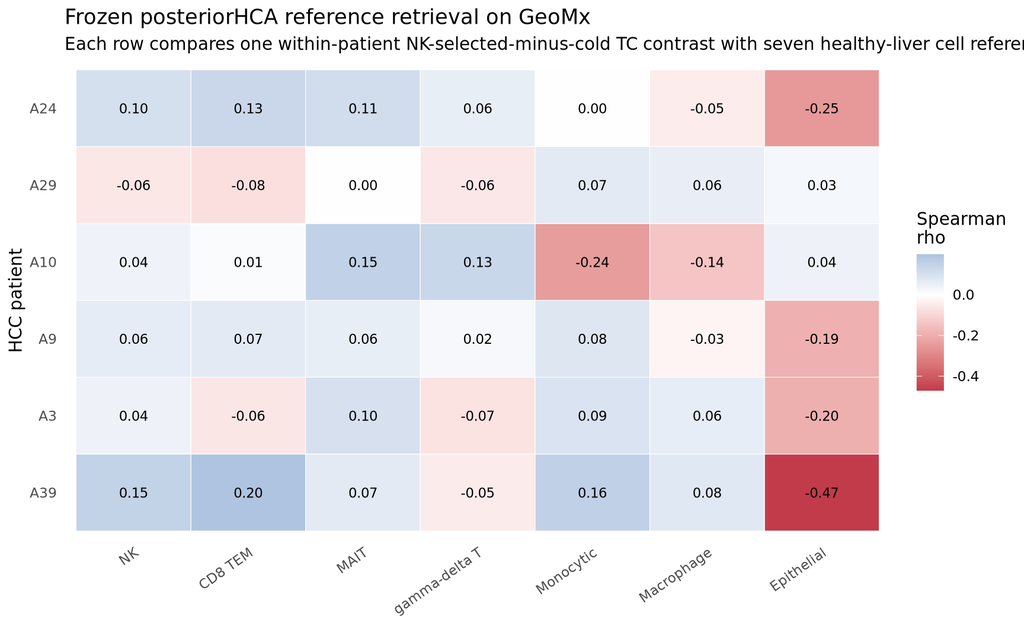

```r
correlation_heatmap <- retrieval_correlations |>
  filter(.data$method == "posteriorHCA") |>
  mutate(
    patient_id = fct_rev(factor(.data$patient_id, levels = primary_patients)),
    cell_label = factor(
      .data$cell_label,
      levels = unname(cell_labels[candidate_cells])
    )
  ) |>
  ggplot(aes(x = .data$cell_label, y = .data$patient_id)) +
  geom_tile(aes(fill = .data$correlation), colour = "white") +
  geom_text(
    aes(label = number(.data$correlation, accuracy = 0.01)),
    size = 3
  ) +
  scale_fill_gradient2(
    low = "#C23B4A",
    mid = "white",
    high = "#2878B5",
    midpoint = 0,
    name = "Spearman\nrho"
  ) +
  labs(
    title = "Frozen posteriorHCA reference retrieval on GeoMx",
    subtitle = "Each row compares one within-patient NK-selected-minus-cold TC contrast with seven healthy-liver cell references",
    x = NULL,
    y = "HCC patient"
  ) +
  theme(
    axis.text.x = element_text(angle = 35, hjust = 1),
    panel.grid = element_blank(),
    legend.position = "right"
  )

correlation_heatmap
```

```r
ggsave(
  file.path(output_dir, "posteriorHCA_reference_correlation_heatmap.pdf"),
  correlation_heatmap,
  width = 9,
  height = 5.5
)
```

The transfer claim requires NK to be the best-matching reference, not merely positively correlated. A positive NK margin means that NK outranks CD8 TEM, MAIT, gamma-delta T, monocytic, macrophage and epithelial references.

## Descriptive sensitivity: posteriorHCA versus a naive empirical centroid

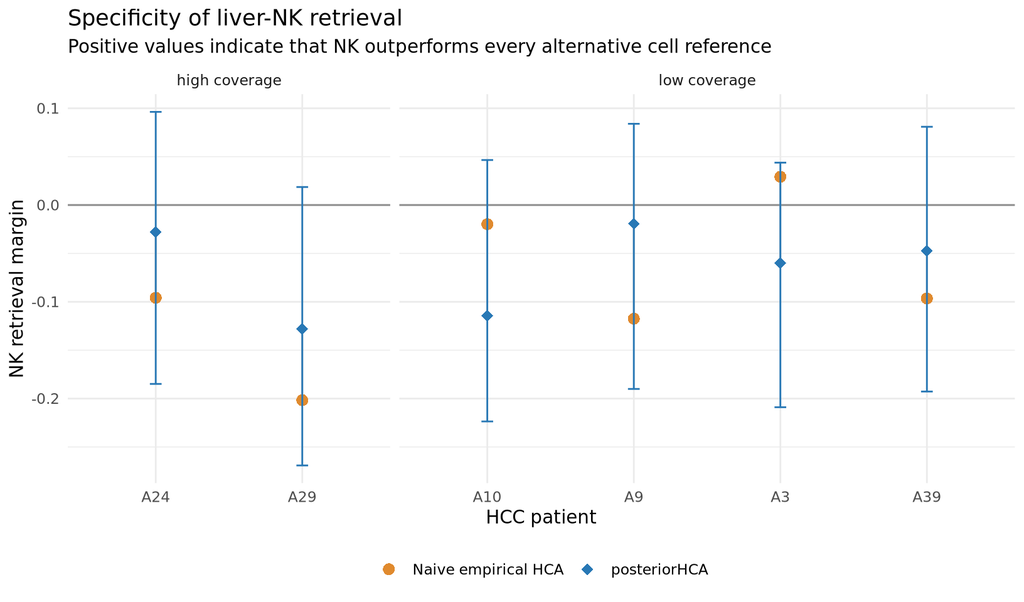

```r
margin_plot_data <- retrieval_metrics |>
  mutate(
    patient_id = factor(.data$patient_id, levels = primary_patients),
    method = factor(
      .data$method,
      levels = c("Naive empirical HCA", "posteriorHCA")
    )
  )

margin_plot <- margin_plot_data |>
  ggplot(aes(x = .data$patient_id, y = .data$nk_margin)) +
  geom_hline(yintercept = 0, colour = "grey55", linewidth = 0.5) +
  geom_line(aes(group = .data$patient_id), colour = "grey70") +
  geom_point(
    aes(colour = .data$method, shape = .data$method),
    size = 3
  ) +
  geom_errorbar(
    data = margin_plot_data |>
      filter(.data$method == "posteriorHCA"),
    aes(ymin = .data$nk_margin_lo, ymax = .data$nk_margin_hi),
    width = 0.08,
    colour = method_colours[["posteriorHCA"]]
  ) +
  facet_grid(cols = vars(.data$panel), scales = "free_x", space = "free_x") +
  scale_colour_manual(values = method_colours) +
  scale_shape_manual(
    values = c(`Naive empirical HCA` = 16, posteriorHCA = 18)
  ) +
  labs(
    title = "Specificity of liver-NK retrieval",
    subtitle = "Positive values indicate that NK outperforms every alternative cell reference",
    x = "HCC patient",
    y = "NK retrieval margin",
    colour = NULL,
    shape = NULL
  ) +
  theme(legend.position = "bottom")

margin_plot
```

```r
ggsave(
  file.path(output_dir, "posteriorHCA_vs_empirical_retrieval_margin.pdf"),
  margin_plot,
  width = 8.5,
  height = 5
)
```

The empirical comparator is intentionally naive. It uses offset-normalized healthy-liver observations and equal dataset weighting, but it does not use the comprehensive factor-grid grand mean or the new-dataset hierarchical draw used by posteriorHCA. Any difference can therefore reflect covariate mix, dataset handling or the log transformation as well as hierarchical modelling. It is shown only to contextualize the frozen reference and cannot establish posteriorHCA superiority.

## Where does the observed labelling fall among alternative allocations?

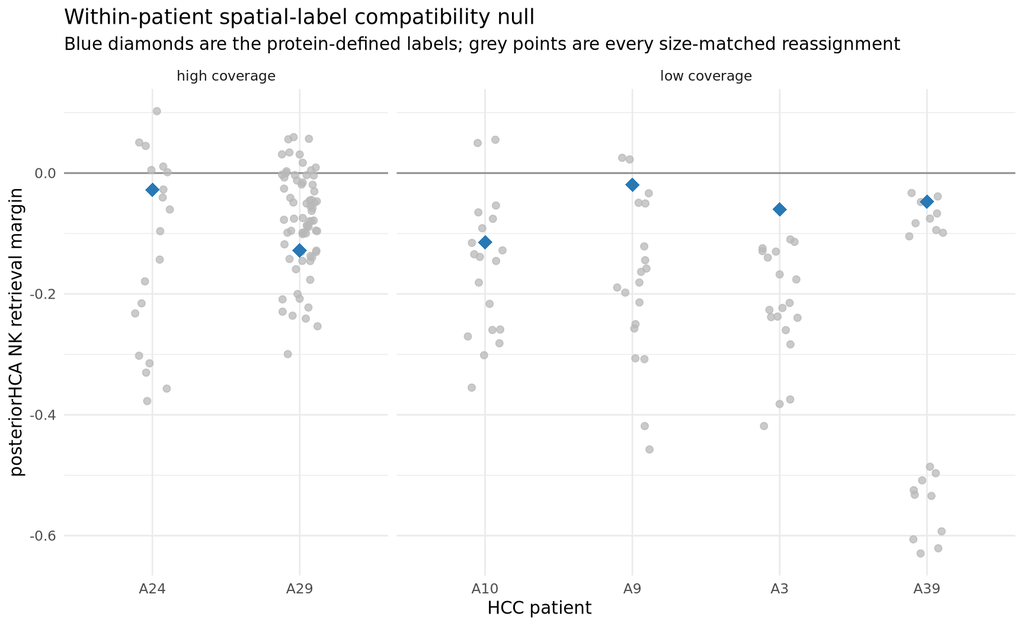

```r
exact_null_plot <- exact_permutations |>
  filter(.data$method == "posteriorHCA") |>
  mutate(
    patient_id = factor(.data$patient_id, levels = primary_patients)
  ) |>
  ggplot(aes(x = .data$patient_id, y = .data$nk_margin)) +
  geom_hline(yintercept = 0, colour = "grey55", linewidth = 0.5) +
  geom_jitter(
    data = function(data) filter(data, !.data$observed_labels),
    width = 0.13,
    height = 0,
    colour = "grey72",
    alpha = 0.75,
    size = 1.8
  ) +
  geom_point(
    data = function(data) filter(data, .data$observed_labels),
    colour = "#2878B5",
    shape = 18,
    size = 4
  ) +
  facet_grid(cols = vars(.data$panel), scales = "free_x", space = "free_x") +
  labs(
    title = "Within-patient spatial-label compatibility null",
    subtitle = "Blue diamonds are the protein-defined labels; grey points are every size-matched reassignment",
    x = "HCC patient",
    y = "posteriorHCA NK retrieval margin"
  )

exact_null_plot
```

```r
ggsave(
  file.path(output_dir, "posteriorHCA_exact_spatial_label_null.pdf"),
  exact_null_plot,
  width = 9,
  height = 5.5
)
```

# Interpretation

```r
posterior_results <- retrieval_metrics |>
  filter(.data$method == "posteriorHCA")

panel_results <- posterior_results |>
  group_by(.data$panel) |>
  summarise(
    n_patients = n(),
    median_nk_correlation = median(.data$nk_correlation),
    median_nk_margin = median(.data$nk_margin),
    patients_with_nk_rank_1 = sum(.data$nk_rank == 1),
    .groups = "drop"
  )

evidence_summary <- tibble(
  evidence = c(
    "Patients with positive posteriorHCA NK correlation",
    "Patients with NK ranked first",
    "Patients with positive NK retrieval margin",
    "Coverage panels with positive median NK margin",
    "Patients with observed-label percentile at least 0.90",
    "Cohort joint-null upper-tail fraction"
  ),
  observed = c(
    paste0(sum(posterior_results$nk_correlation > 0), " / ", nrow(posterior_results)),
    paste0(sum(posterior_results$nk_rank == 1), " / ", nrow(posterior_results)),
    paste0(sum(posterior_results$nk_margin > 0), " / ", nrow(posterior_results)),
    paste0(sum(panel_results$median_nk_margin > 0), " / ", nrow(panel_results)),
    paste0(
      sum(
        exact_test_summary$method == "posteriorHCA" &
          exact_test_summary$observed_percentile >= 0.90
      ),
      " / ",
      sum(exact_test_summary$method == "posteriorHCA")
    ),
    format(
      joint_null_summary$monte_carlo_upper_tail[
        joint_null_summary$method == "posteriorHCA"
      ],
      digits = 3
    )
  )
)

evidence_summary
```

| evidence | observed |
| --- | --- |
| Patients with positive posteriorHCA NK correlation | 5 / 6 |
| Patients with NK ranked first | 0 / 6 |
| Patients with positive NK retrieval margin | 0 / 6 |
| Coverage panels with positive median NK margin | 0 / 2 |
| Patients with observed-label percentile at least 0.90 | 3 / 6 |
| Cohort joint-null upper-tail fraction | 0.0175 |

Evidence for cross-platform transport is strongest when the following pattern appears together:

1. the liver-NK correlation is positive;
2. NK ranks first among all seven cell references, giving a positive margin;
3. the result is present in both GeoMx coverage panels;
4. the observed spatial labels lie near the top of their exhaustive compatibility null; and
5. the pattern remains after source-gene, TIMES-gene and segmentation-marker exclusion.

The posterior-draw intervals and positive-margin probability are conditional on the frozen fitted models and the fixed HCC contrasts. They represent reference-model sensitivity, not total uncertainty and not GeoMx calibration. The naive empirical centroid is descriptive context only; this experiment does not use it to claim superiority of hierarchical modelling.

Even a strong result remains a structural validation. GeoMx Q3 values are not raw counts, the regions are mixed-cell spatial samples, and no healthy GeoMx or paired cross-platform bridge exists. Consequently, this report does not call the baseline absolutely calibrated to GeoMx.

# Claim–evidence map

| Claim | Required evidence in this report | Status rule |
| --- | --- | --- |
| Frozen posteriorHCA structure transfers to unseen GeoMx | Positive NK correlation and margin, both coverage panels, source-excluded genes and label-null support | Strongly supported only if all evidence classes agree and a useful all-seven-PASS gene universe exists; otherwise exploratory |
| Transfer is NK-specific | NK outranks CD8 TEM, MAIT, gamma-delta T, monocytic, macrophage and epithelial references | Supported patient by patient by a positive NK margin |
| posteriorHCA improves on a direct HCA centroid | A covariate- and estimand-matched direct reference comparison | Not tested; the naive empirical sensitivity is not a fair superiority benchmark |
| posteriorHCA is absolutely calibrated to GeoMx | Healthy or paired cross-platform bridge and valid GeoMx observation model | Not testable with the available data |

# Reviewer-facing self-review

[output not shown]

# Saved artefacts

```r
output_files <- tibble(
  file = list.files(
    output_dir,
    full.names = TRUE,
    recursive = TRUE,
    include.dirs = FALSE
  ),
  size_mb = file.info(file)$size / 1024^2
) |>
  mutate(size_mb = round(.data$size_mb, 2)) |>
  arrange(.data$file)

output_files
```

[output not shown]

[output cut: 2778 more lines]